# Chapter 5 Homework

Joe Dickerson

2025-09-21

Problem 8.

n = 100 p = 2

y = x - 2x^2

```r
set.seed(1)
x <- rnorm(100)
y <- x - 2 * x^2 + rnorm(100)
```

There appears to be a quadratic relationship (nonlinear) between x and y.

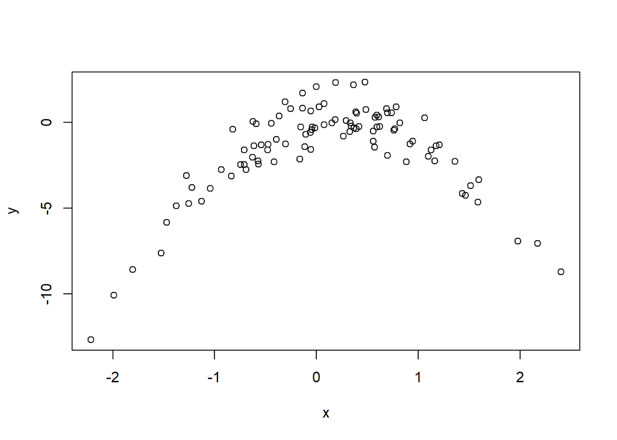

```r
plot(x=x, y=y)
```

We find the LOOCV errors to be 7.29, 0.94, 0.96, and 0.95.

```r
library(boot)

set.seed(123)

data <- data.frame(y = y, x = x)

glm <- glm(y ~ x)
cv.err <- cv.glm(data, glm)
cv.err$delta
```

```
## [1] 7.288162 7.284744
```

```r
cv.error <- rep(0, 4)

for (i in 1:4) {
  glm.fit <- glm(y ~ poly(x, i), data = data)
  cv.error[i] <- cv.glm(data, glm.fit)$delta[1]
}

cv.error
```

```
## [1] 7.2881616 0.9374236 0.9566218 0.9539049
```

The results are the same because LOOCV does not use random elements.

```r
set.seed(100)

data <- data.frame(y = y, x = x)

glm <- glm(y ~ x)
cv.err <- cv.glm(data, glm)
cv.err$delta
```

```
## [1] 7.288162 7.284744
```

```r
cv.error <- rep(0, 4)

for (i in 1:4) {
  glm.fit <- glm(y ~ poly(x, i), data = data)
  cv.error[i] <- cv.glm(data, glm.fit)$delta[1]
}

cv.error
```

```
## [1] 7.2881616 0.9374236 0.9566218 0.9539049
```

Model ii., which was Y = B0 + B1X + B2X^2 + Error, technically fit best, though all the quadratic models fit almost identically. This is probably due to the data having a quadratic fit, if we recall the plot from part b.

```r
library(tidyverse)
```

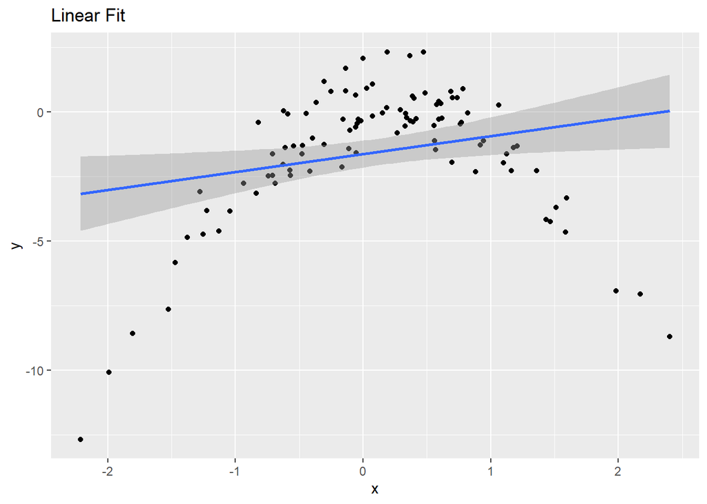

```r
data %>%
  ggplot(aes(x = x, y = y)) +
  geom_point() +
  geom_smooth(method = "lm") +
  labs(title = "Linear Fit")
```

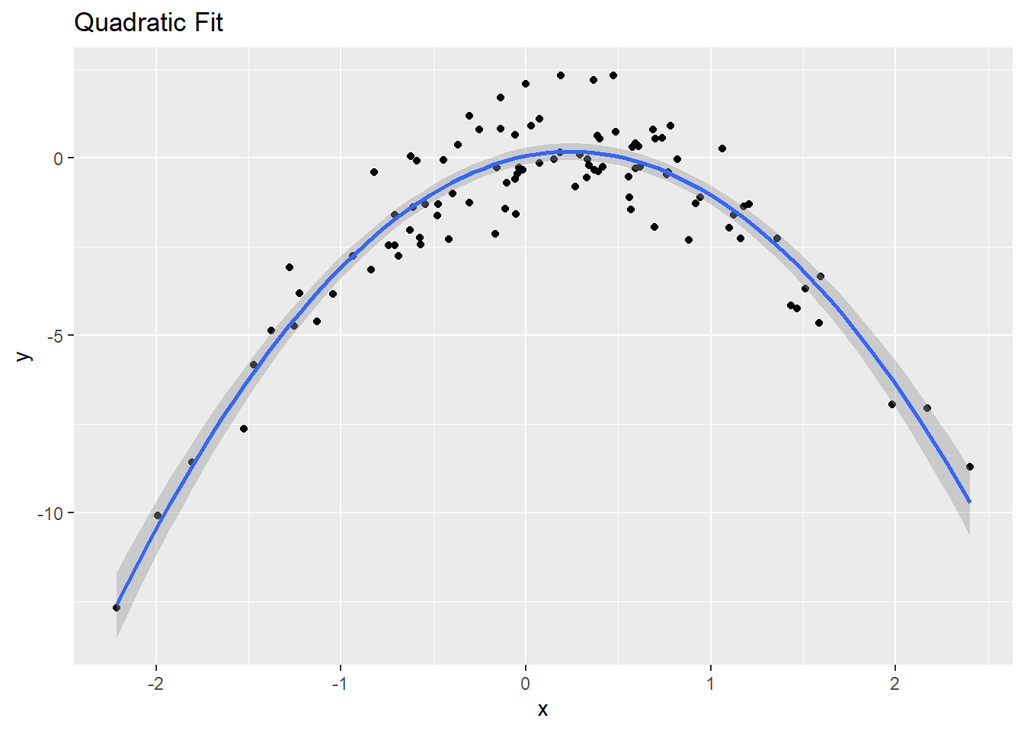

```r
data %>%
  ggplot(aes(x = x, y = y)) +
  geom_point() +
  geom_smooth(method = "lm", formula = "y ~ x + I(x^2)") +
  labs(title = "Quadratic Fit")
```

We see much greater significance in the second model than the first with the inclusion of a quadratic term. However, we see no greater significance in the following models. These results agree with the cross-validation conclusions. The second model is the best fit.

```r
glm1 <- glm(y ~ x, data = data)
summary(glm1)
```

```
##
## Call:
## glm(formula = y ~ x, data = data)
##
## Coefficients:
##             Estimate Std. Error t value Pr(>|t|)
## (Intercept)  -1.6254     0.2619  -6.205 1.31e-08 ***
## x             0.6925     0.2909   2.380   0.0192 *
## ---
## Signif. codes:  0 '***' 0.001 '**' 0.01 '*' 0.05 '.' 0.1 ' ' 1
##
## (Dispersion parameter for gaussian family taken to be 6.760719)
##
##     Null deviance: 700.85  on 99  degrees of freedom
## Residual deviance: 662.55  on 98  degrees of freedom
## AIC: 478.88
##
## Number of Fisher Scoring iterations: 2
```

```r
glm2 <- glm(y ~ x + I(x^2), data = data)
summary(glm2)
```

```
##
## Call:
## glm(formula = y ~ x + I(x^2), data = data)
##
## Coefficients:
##             Estimate Std. Error t value Pr(>|t|)
## (Intercept)  0.05672    0.11766   0.482    0.631
## x            1.01716    0.10798   9.420  2.4e-15 ***
## I(x^2)      -2.11892    0.08477 -24.997  < 2e-16 ***
## ---
## Signif. codes:  0 '***' 0.001 '**' 0.01 '*' 0.05 '.' 0.1 ' ' 1
##
## (Dispersion parameter for gaussian family taken to be 0.9178258)
##
##     Null deviance: 700.852  on 99  degrees of freedom
## Residual deviance:  89.029  on 97  degrees of freedom
## AIC: 280.17
##
## Number of Fisher Scoring iterations: 2
```

```r
glm3 <- glm(y ~ x + I(x^2) + I(x^3), data = data)
summary(glm3)
```

```
##
## Call:
## glm(formula = y ~ x + I(x^2) + I(x^3), data = data)
##
## Coefficients:
##             Estimate Std. Error t value Pr(>|t|)
## (Intercept)  0.06151    0.11950   0.515    0.608
## x            0.97528    0.18728   5.208 1.09e-06 ***
## I(x^2)      -2.12379    0.08700 -24.411  < 2e-16 ***
## I(x^3)       0.01764    0.06429   0.274    0.784
## ---
## Signif. codes:  0 '***' 0.001 '**' 0.01 '*' 0.05 '.' 0.1 ' ' 1
##
## (Dispersion parameter for gaussian family taken to be 0.9266599)
##
##     Null deviance: 700.852  on 99  degrees of freedom
## Residual deviance:  88.959  on 96  degrees of freedom
## AIC: 282.09
##
## Number of Fisher Scoring iterations: 2
```

```r
glm4 <- glm(y ~ x + I(x^2) + I(x^3) + I(x^4), data = data)
summary(glm4)
```

```
##
## Call:
## glm(formula = y ~ x + I(x^2) + I(x^3) + I(x^4), data = data)
##
## Coefficients:
##              Estimate Std. Error t value Pr(>|t|)
## (Intercept)  0.156703   0.139462   1.124    0.264
## x            1.030826   0.191337   5.387 5.17e-07 ***
## I(x^2)      -2.409898   0.234855 -10.261  < 2e-16 ***
## I(x^3)      -0.009133   0.067229  -0.136    0.892
## I(x^4)       0.069785   0.053240   1.311    0.193
## ---
## Signif. codes:  0 '***' 0.001 '**' 0.01 '*' 0.05 '.' 0.1 ' ' 1
##
## (Dispersion parameter for gaussian family taken to be 0.9197797)
##
##     Null deviance: 700.852  on 99  degrees of freedom
## Residual deviance:  87.379  on 95  degrees of freedom
## AIC: 282.3
##
## Number of Fisher Scoring iterations: 2
```

Problem 9.

1. μ-hat = 22.53

```r
library(ISLR2)
data(Boston)

mean(Boston$medv)
```

```
## [1] 22.53281
```

The estimated standard error of μ-hat is 0.409.

```r
sd(Boston$medv) / sqrt(length(Boston$medv))
```

```
## [1] 0.4088611
```

```r
set.seed(123)

boot.fn <- function(vector, index){
  mean(vector[index])
}

boot(data = Boston$medv, statistic = boot.fn, R = 1000)
```

```
##
## ORDINARY NONPARAMETRIC BOOTSTRAP
##
##
## Call:
## boot(data = Boston$medv, statistic = boot.fn, R = 1000)
##
##
## Bootstrap Statistics :
##     original      bias    std. error
## t1* 22.53281 -0.01607372   0.4045557
```

```r
boot <- boot(data = Boston$medv, statistic = boot.fn, R = 1000)

boot.se <- sd(boot$t)

c(mean(Boston$medv) - 2*boot.se, mean(Boston$medv) + 2*boot.se)
```

```
## [1] 21.71127 23.35435
```

```r
t.test(Boston$medv)
```

```
##
##  One Sample t-test
##
## data:  Boston$medv
## t = 55.111, df = 505, p-value < 2.2e-16
## alternative hypothesis: true mean is not equal to 0
## 95 percent confidence interval:
##  21.72953 23.33608
## sample estimates:
## mean of x
##  22.53281
```

5. The median u-hat-med is 21.2.

```r
median(Boston$medv)
```

```
## [1] 21.2
```

We get a standard error of 0.38, which is somewhat similar to the standard error we got of the mean.

```r
boot.fn <- function(vector, index){
  median(vector[index])
}

boot(data = Boston$medv, statistic = boot.fn, R = 1000)
```

```
##
## ORDINARY NONPARAMETRIC BOOTSTRAP
##
##
## Call:
## boot(data = Boston$medv, statistic = boot.fn, R = 1000)
##
##
## Bootstrap Statistics :
##     original  bias    std. error
## t1*     21.2 -0.0187   0.3810321
```

Using the quantile function, the estimate of the tenth percentile is 12.75.

```r
quantile(Boston$medv, 0.1)
```

```
##   10%
## 12.75
```

```r
boot.fn <- function(vector, index){
  quantile(vector[index], 0.1)
}

boot(data = Boston$medv, statistic = boot.fn, R = 1000)
```

```
##
## ORDINARY NONPARAMETRIC BOOTSTRAP
##
##
## Call:
## boot(data = Boston$medv, statistic = boot.fn, R = 1000)
##
##
## Bootstrap Statistics :
##     original  bias    std. error
## t1*    12.75  0.0209   0.4931545
```